# アカデミアのためのRSTUDIO

### JAMA カラー

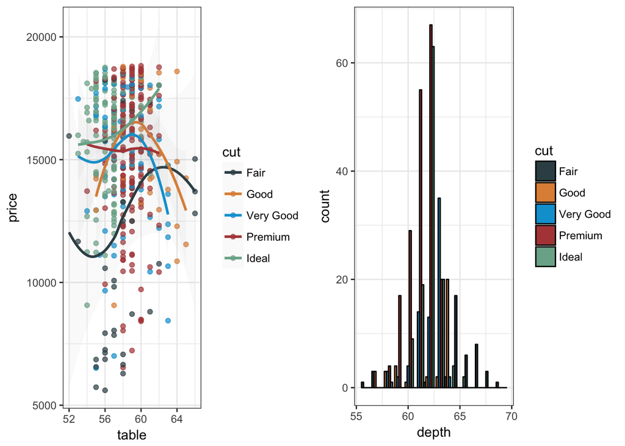

```r
p1_jama = p1 + scale_color_jama()
p2_jama = p2 + scale_fill_jama()
grid.arrange(p1_jama, p2_jama, ncol = 2)
```

# 解析結果の報告ツール (sigr, psycho)

解析の統計量を文中に挿入する際に, 転記ミスが生じやすいものです。RStudioで解析した結果からそのまま数値を取ってきて文章に挿入するとそのようなエラーが減ります。

そのような志向のパッケージに, sigr(https://github.com/WinVector/sigr)やpsycho(https://github.com/neuropsychology/psycho.R)パッケージがあります。

例えば, 一般化線形モデルの解析結果の統計量を報告する際には

```r
library(sigr)

d <- data.frame(x=c(1,2,3,4,5,6,7,7),
      y=c(TRUE,FALSE,FALSE,FALSE,TRUE,TRUE,TRUE,FALSE))
model <- glm(y~x,data=d,family=binomial)
summary(model)
```

[output not shown]

sigrのwrapChiSqTestを使って

```r
cat(render(wrapChiSqTest(model),
           pLargeCutoff=1, format='markdown'))
```

**Chi-Square Test** summary: *pseudo-*R<sup>2</sup>**=0.023 (*χ<sup>2</sup>*(1,*N*=8)=0.25, *p*=0.61).

と, 統計量を含んだ文を生成してくれます。

# 便利ツール (wordcount, gramr)

その他に, 論文作成のために便利なaddinを紹介します。

- wordcount
  - 文字カウントをしてくれます。
- gramr
  - 文法チェックをしてくれます。

# 最後に

後半, パッケージ名のみの紹介になってしまいましたが, 論文作成周りのパッケージが徐々に充実してきているように思います。私もまだまだつまずくことが多々ありますが, とりあえずテンプレートにそっておおよその形は作っていけるかと思います。解析結果をそのまま埋め込んでいける感じがやっぱ良いです。

Enjoy, Writing Manuscripts with RStudio !!

# reference

Allaire, JJ, R Foundation, Hadley Wickham, Journal of Statistical Software, Yihui Xie, Ramnath Vaidyanathan, Association for Computing Machinery, et al. 2017. *Rticles: Article Formats for R Markdown*. https://CRAN.R-project.org/package=rticles.

Allaire, JJ, Yihui Xie, Jonathan McPherson, Javier Luraschi, Kevin Ushey, Aron Atkins, Hadley Wickham, Joe Cheng, and Winston Chang. 2017. *Rmarkdown: Dynamic Documents for R*. https://CRAN.R-project.org/package=rmarkdown.

Aust, Frederik, and Marius Barth. 2017. *papaja: Create APA Manuscripts with R Markdown*. https://github.com/crsh/papaja.